# Principal component analysis (PCA)

25 February 2021

## PCA and PCR

The data frame `USairpollution` in the R package `HSAUR2` contains air pollution data of 41 US cities.

```r
library(HSAUR2)
head(USairpollution)
```

```
##             SO2 temp manu popul wind precip predays
## Albany       46 47.6   44   116  8.8  33.36     135
## Albuquerque  11 56.8   46   244  8.9   7.77      58
## Atlanta      24 61.5  368   497  9.1  48.34     115
## Baltimore    47 55.0  625   905  9.6  41.31     111
## Buffalo      11 47.1  391   463 12.4  36.11     166
## Charleston   31 55.2   35    71  6.5  40.75     148
```

```r
attach(USairpollution)
```

The question of most interest about these data is probably how the pollution level as measured by sulphur dioxide concentration (`SO2`) is related to the six other variables. However, we first ignore the `SO2` variable and concentrate on the others, two of which relate to human ecology (`popul`,`manu`) and four to climate (`temp`, `wind`, `precip`, `predays`). We replace the `temp` by a variable representing negative temperatures, since then all six variables are such that high values represent a less attractive environment.

```r
USairpollution$negtemp <- temp*(-1)
USairpollution <- USairpollution[,c(1,8,3:7)]
attach(USairpollution)
head(USairpollution)
```

```
##             SO2 negtemp manu popul wind precip predays
## Albany       46   -47.6   44   116  8.8  33.36     135
## Albuquerque  11   -56.8   46   244  8.9   7.77      58
## Atlanta      24   -61.5  368   497  9.1  48.34     115
## Baltimore    47   -55.0  625   905  9.6  41.31     111
## Buffalo      11   -47.1  391   463 12.4  36.11     166
## Charleston   31   -55.2   35    71  6.5  40.75     148
```

```r
round(cor(USairpollution[,-1]),2) # sample correlation matrix
```

```
##         negtemp  manu popul  wind precip predays
## negtemp    1.00  0.19  0.06  0.35  -0.39    0.43
## manu       0.19  1.00  0.96  0.24  -0.03    0.13
## popul      0.06  0.96  1.00  0.21  -0.03    0.04
## wind       0.35  0.24  0.21  1.00  -0.01    0.16
## precip    -0.39 -0.03 -0.03 -0.01   1.00    0.50
## predays    0.43  0.13  0.04  0.16   0.50    1.00
```

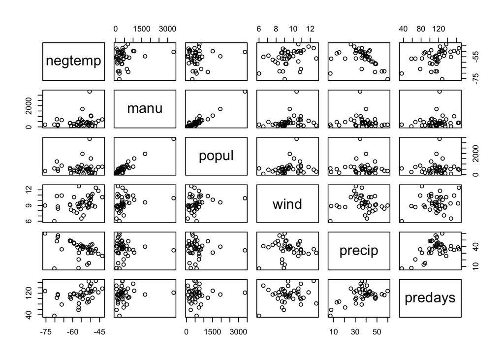

```r
plot(USairpollution[,-1]) # matrix scatterplot
```

#### PCA

We carry on with a PCA of the data for all 41 cities. We take the correlation matrix as an input for PCA as the six variables are measured on very different scales.

```r
usair.pc<-princomp(USairpollution[,-1],cor=TRUE)
summary(usair.pc,loadings=TRUE)
```

```
## Importance of components:
##                           Comp.1    Comp.2    Comp.3    Comp.4     Comp.5
## Standard deviation     1.4819456 1.2247218 1.1809526 0.8719099 0.33848287
## Proportion of Variance 0.3660271 0.2499906 0.2324415 0.1267045 0.01909511
## Cumulative Proportion  0.3660271 0.6160177 0.8484592 0.9751637 0.99425879
##                             Comp.6
## Standard deviation     0.185599752
## Proportion of Variance 0.005741211
## Cumulative Proportion  1.000000000
##
## Loadings:
##         Comp.1 Comp.2 Comp.3 Comp.4 Comp.5 Comp.6
## negtemp  0.330  0.128  0.672  0.306  0.558  0.136
## manu     0.612 -0.168 -0.273  0.137  0.102 -0.703
## popul    0.578 -0.222 -0.350                0.695
## wind     0.354  0.131  0.297 -0.869 -0.113
## precip          0.623 -0.505 -0.171  0.568
## predays  0.238  0.708         0.311 -0.580
```

The first three PCs all have variances greater than one and together account for almost 85% of the variance of the original variables. The loadings are scaled such that their sum of squares is unity (blanks indicate near zero values).

**Interpretation of PCs**

1st component: some index of “quality of life” (QoL) with high values indicating a relatively “poor” environment.

2nd component: high coefficients for `precip` and `predays`, and might be labeled as the “wet weather” component.

3rd component: Contrast between `precip` and `negtemp`, and will separate cities having high temperatures and high rainfall from those that are colder but drier. A suitable label might be simply “climate type”.

**PC scores**

```r
usair.pc$scores[,1:3]
```

```
##                      Comp.1      Comp.2      Comp.3
## Albany         -0.538945616  0.79206938  1.36260519
## Albuquerque    -1.417093145 -2.86589024  1.27540034
## Atlanta        -0.598994755  0.58723563 -0.99541128
## Baltimore       0.509380032  0.02875397 -0.36359953
## Buffalo         1.390708909  1.88030104  1.77619191
## Charleston     -1.429753320  1.21058365 -0.07944350
## Chicago         6.513881753 -1.66838172 -2.28629587
## Cincinnati     -0.508220797  0.48601020 -0.26618169
## Cleveland       1.766279326  1.03942658  0.74664124
## Columbus       -0.118835030  0.64039358  0.42302559
## Dallas         -0.006878799 -1.21181090 -0.99830140
## Denver         -0.207434109 -1.96320936  1.26621359
## Des Moines     -0.131980292 -0.06120607  1.65010856
## Detroit         2.166694857 -0.27060292  0.14704284
## Hartford       -0.219106349  0.97630584  0.59461329
## Houston         0.508419801 -0.11271579 -1.99360553
## Indianapolis    0.308324007  0.36049244  0.28541539
## Jacksonville   -1.227849872  0.84912801 -1.87611109
## Kansas City    -0.131303464 -0.25205976  0.27549603
## Little Rock    -1.611599761  0.34248684 -0.83970812
## Louisville     -0.423739264  0.54055336 -0.37446946
## Memphis        -0.577848813  0.32506654 -1.11488311
## Miami          -1.533160553  1.40469861 -2.60660585
## Milwaukee       1.391024518  0.15761872  1.69127813
## Minneapolis     1.500032786  0.24675569  1.75081328
## Nashville      -0.910052287  0.54346445 -0.85923113
## New Orleans    -1.453857066  0.90075225 -1.99187430
## Norfolk        -0.589141903  0.75219052 -0.06092797
## Omaha          -0.133637672 -0.38478358  1.23581021
## Philadelphia    2.797074676 -0.65847826 -1.41511547
## Phoenix        -2.440096802 -4.19114925 -0.94155229
## Pittsburgh      0.322264830  1.02663680  0.74808213
## Providence      0.069936477  1.03390711  0.88774002
## Richmond       -1.171998946  0.33494902 -0.50862036
## Salt Lake City -0.912393969 -1.54734758  1.56510204
## San Francisco  -0.502073845 -2.25528717  0.22663991
## Seattle         0.481679438  1.59742576  0.60871204
## St. Louis       0.286187330 -0.38438239 -0.15567183
## Washington     -0.022928417 -0.05456742 -0.35387289
## Wichita        -0.196823158 -0.67607441  1.13122963
## Wilmington     -0.996140738  0.50074082  0.43332129
```

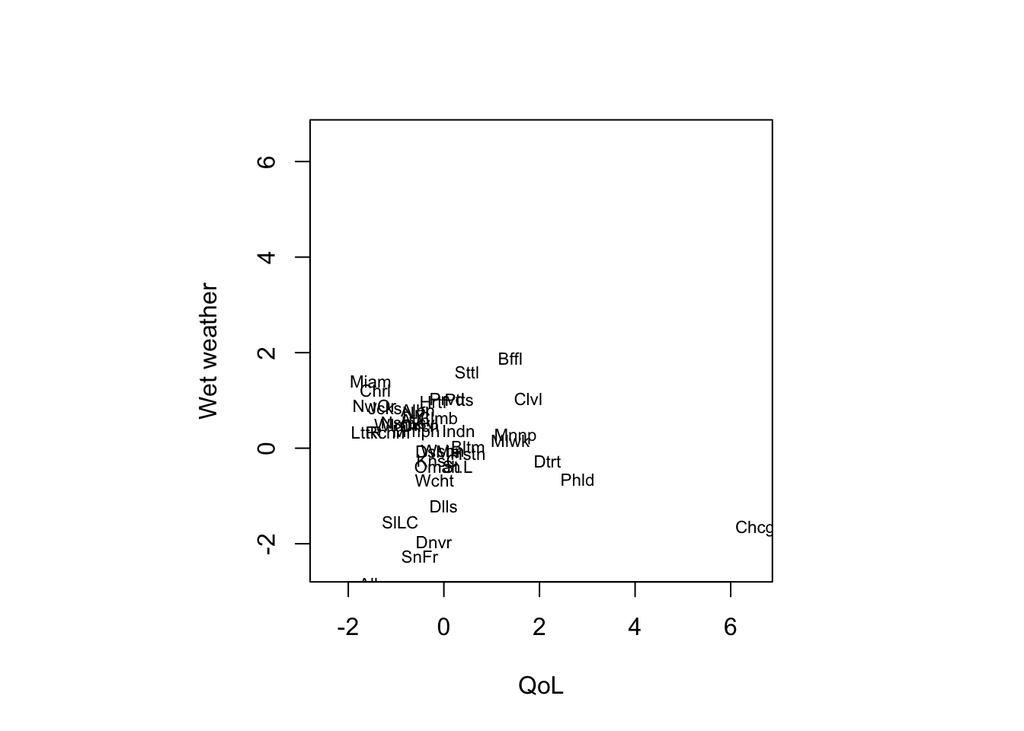

```r
par(pty="s")
plot(usair.pc$scores[,1],usair.pc$scores[,2],
ylim=range(usair.pc$scores[,1]),
xlab="QoL",ylab="Wet weather",type="n",lwd=2)
text(usair.pc$scores[,1],usair.pc$scores[,2],
labels=abbreviate(row.names(USairpollution)),cex=0.7,lwd=2)
```

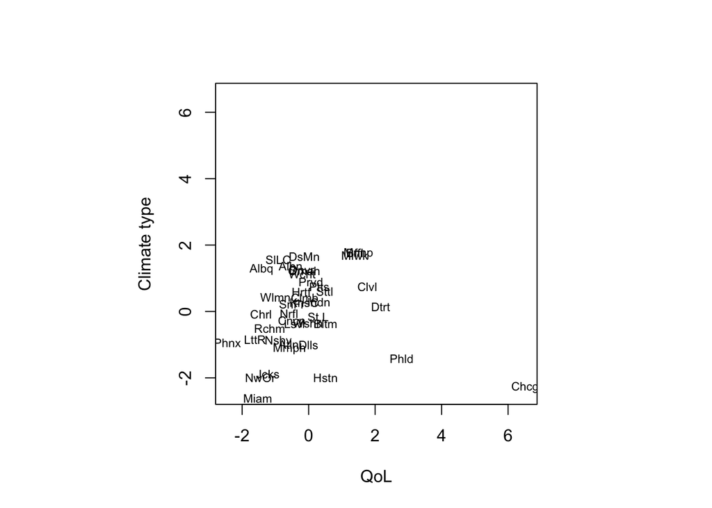

```r
par(pty="s")
plot(usair.pc$scores[,1],usair.pc$scores[,3],
ylim=range(usair.pc$scores[,1]),
xlab="QoL",ylab="Climate type",type="n",lwd=2)
text(usair.pc$scores[,1],usair.pc$scores[,3],
labels=abbreviate(row.names(USairpollution)),cex=0.7,lwd=2)
```

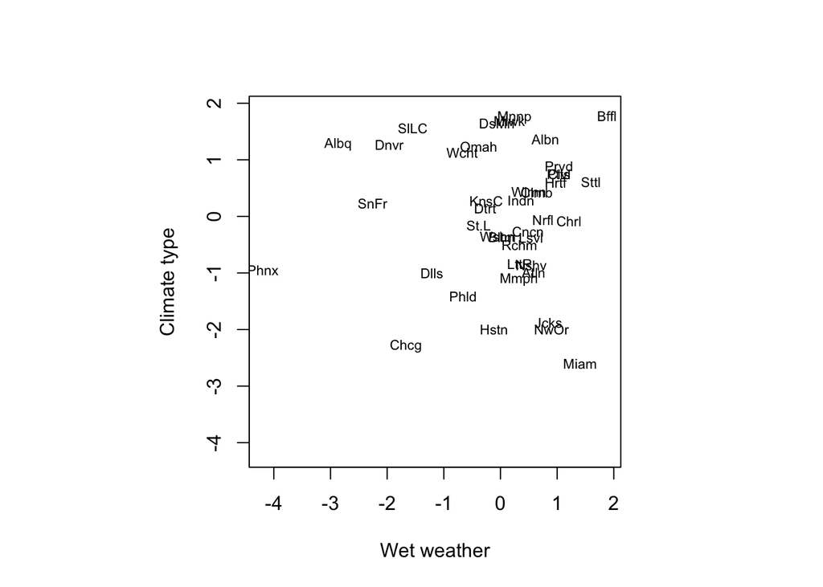

```r
par(pty="s")
plot(usair.pc$scores[,2],usair.pc$scores[,3],
ylim=range(usair.pc$scores[,2]),
xlab="Wet weather",ylab="Climate type",type="n",lwd=2)
text(usair.pc$scores[,2],usair.pc$scores[,3],
labels=abbreviate(row.names(USairpollution)),cex=0.7,lwd=2)
```